# Model ReverseAnalysis

Masaki Open Lab

2019年8月22日

Firstly we open the “Sample data GP” file and remove rows with missing values.

```r
#-----------pick up the file path--------------
path <- "C:/Users/uni/Desktop/Folders/Data Science Seminar/sample data/Sample data GP.csv"

#-----------read csv file as compounds--------------
compounds <- read.csv(path)

#-----------remove some columns if needed--------------
trimed.compounds <- compounds[,]

#-----------select rows without empty cells---------
is.completes <- complete.cases(trimed.compounds)
complete.compounds <- trimed.compounds[is.completes,]
```

Now let’s check the complete dataset (first 5 rows).

```r
complete.compounds[c(1:5),]
```

```
##          y    a1    a2    a3    a4    a5    a6   a7   a8  a9      a10
## 1 2.590267 0.175 0.003 47.55 0.175 0.225 0.335  800 1.87 777 1.824885
## 2 2.590267 0.175 0.003 47.55 0.175 0.225 0.335  800 1.87 776 1.833333
## 3 2.590267 0.175 0.003 47.55 0.175 0.225 0.335  800 1.87 781 1.867925
## 4 2.590267 0.175 0.003 47.55 0.175 0.225 0.335  800 1.87 778 1.942857
## 5 2.551046 0.175 0.003 48.10 0.020 0.240 0.335 1000 1.83 777 2.019231
##        a11        a12        a13 a14 a15
## 1 24.27650 0.01658986 0.08847926 2.3 9.6
## 2 24.33333 0.01666667 0.08888889 2.3 9.8
## 3 24.50943 0.01698113 0.09056604 2.3 9.3
## 4 24.45714 0.01714286 0.09714286 2.3 9.9
## 5 24.34615 0.01730769 0.09807692 2.3 9.5
```

Next we define the predictor variable x, y and remove the columns of 0 distribution (which is not importand in the prediction model).

```r
#-----------select x from the dataset-----------------
x <- complete.compounds[,-c(1)]
x <- cbind.data.frame(x)

#-----------remove columns of 0 distribution from x----
x.sds <- apply(x, 2, sd)
sd.is.not.0 <- x.sds != 0
x <- x[, sd.is.not.0]

#-----------select y from the dataset------------------
y <- complete.compounds[,c(1)]
```

Then we standarize both x and y below.

```r
#-----------standarization of y------------------------
preprocessed.y <- (y - mean(y)) / sd(y)
mean(preprocessed.y)
```

```
## [1] 2.545764e-16
```

```r
sd(preprocessed.y)
```

```
## [1] 1
```

```r
#-----------standarization of x------------------------
apply(x, 2, mean)
```

```
##           a1           a2           a3           a4           a5
## 1.742841e-01 4.242612e-03 4.860017e+01 4.775487e-02 2.249599e-01
##           a6           a7           a8           a9          a10
## 3.394759e-01 8.579611e+02 1.919759e+00 7.756964e+02 2.204888e+00
##          a11          a12          a13          a14          a15
## 2.491645e+01 1.430493e-02 1.174357e-01 2.240046e+00 9.747308e+00
```

```r
apply(x, 2, sd)
```

```
##           a1           a2           a3           a4           a5
## 5.177752e-03 2.458596e-03 6.795231e-01 4.821349e-02 8.613698e-02
##           a6           a7           a8           a9          a10
## 6.297207e-03 1.202404e+02 4.738841e-01 9.256448e+00 3.561697e-01
##          a11          a12          a13          a14          a15
## 1.405109e+00 7.297394e-03 3.053688e-02 6.426720e-02 5.102349e-01
```

```r
preprocessed.x <- apply(x, 2, function(x) {(x - mean(x)) / sd(x)})
preprocessed.x <- data.frame(preprocessed.x)

#-----------compare the number of columns and rows--------------
ncol(preprocessed.x)
```

```
## [1] 15
```

```r
nrow(preprocessed.x)
```

```
## [1] 873
```

Next we set up train / test datasets. Train data is used for constructing model, Test data is used for checking the prediction accuracy of the model. Today we set the train_size = 0.5 (50% of the dataset used for the train data).

```r
#-----------pick up columns if needed---------------------------
multi.regression.x <- preprocessed.x[ , ]

#-----------definition of multi.regression.compounds (used for MLR)--------
multi.regression.compounds <- cbind(preprocessed.y, multi.regression.x)

#--------------------divide into test and training data----------------------
train_size = 0.5

n = nrow(multi.regression.compounds)
#------------collect the data with n*train_size from the dataset------------
perm = sample(n, size = round(n * train_size))

#-------------------training data----------------------------------------
multi.regression.compounds.train <- multi.regression.compounds[perm, ]
preprocessed.y.train <- multi.regression.compounds.train[,c(1)]
multi.regression.x.train <- multi.regression.compounds.train[,-c(1)]
#-----------------------test data----------------------------------------
multi.regression.compounds.test <-multi.regression.compounds[-perm, ]
preprocessed.y.test <- multi.regression.compounds.test[,c(1)]
multi.regression.x.test <- multi.regression.compounds.test[,-c(1)]

#-----------transform into data frame--------------------------
multi.regression.compounds.train <- as.data.frame(multi.regression.compounds.train)
```

We use SVM model with stepwise variables selection method. If you’re interested in the mechanism of the mechanism, please check the reference site. https://www.youtube.com/watch?v=y41brn00nsM&list=PLqjwhcbgOLLjWHG5wiwBPpzeBr5hlfqP6&index=9

```r
#-------------Installing SVM library---------------------------------
library(e1071)
library(kernlab)
library(iml)
library(devtools)
#---------------------------stepwise variables selection--------------------------------------------
#Generating initial dataset(train and test)
multi.regression.compounds.train.s <- cbind(preprocessed.y.train, multi.regression.x.train[,])
multi.regression.x.train.s <- multi.regression.x.train[,]
multi.regression.compounds.test.s <- cbind(preprocessed.y.test,multi.regression.x.test)
multi.regression.x.test.s <- multi.regression.x.test[,]

#Definition of best performance data for each cases
best.performance.cv <- matrix(data = 0, nrow = ncol(multi.regression.x.train), ncol = 3)
best.performance.cv[,c(3)] <- seq(1:ncol(multi.regression.x.train))
variables.step <- colnames(preprocessed.x)
importances <- matrix(data = 0, nrow = ncol(multi.regression.x.train), ncol = ncol(multi.regression.x.train))
rownames(importances) <- colnames(preprocessed.x)
```

```r
for(j in 1:(ncol(preprocessed.x) - 7)){ #the process stops when variable number becomes 7 (determined from best performance curve)

  #SVM hyperparameter tuning
  #determining initial gamma by maximizing kernel matrix variance
  gam <- matrix(data = 0, nrow = 31, ncol = 1)
  for(k in -20:10){
    rbf <- rbfdot(sigma = 2^k)
    rbf

    asmat <- as.matrix(multi.regression.x.train.s)
    asmat

    kern <- kernelMatrix(rbf, asmat)
    sd(kern)
    gam[c(k + 21),] <- sd(kern)
  }

  hakata <- which.max(gam)

  obj.se <- tune.svm(preprocessed.y.train~., data = multi.regression.compounds.train.s, gamma = 2^(hakata - 21), cost = 3, epsilon = 2^(-10:0))
  obj.sc <- tune.svm(preprocessed.y.train~., data = multi.regression.compounds.train.s, gamma = 2^(hakata - 21), cost = 2^(-5:10), epsilon = obj.se$best.parameters[,c(3)])
  obj.s <- tune.svm(preprocessed.y.train~., data = multi.regression.compounds.train.s, gamma = 2^(-20:10), cost = obj.sc$best.parameters[,c(2)], epsilon = obj.se$best.parameters[,c(3)])
  compounds.svr.s <- svm(multi.regression.x.train.s,preprocessed.y.train,gammma = obj.s$best.parameters[,c(1)], cost = obj.s$best.parameters[,c(2)], epsilon = obj.s$best.parameters[,c(3)])
  summary(compounds.svr.s)
  best.performance.cv[c(j), c(1)] <- obj.s$performances[which.min(obj.s$performances[,c(4)]), c(4)]
  best.performance.cv[c(j), c(2)] <- obj.s$performances[which.min(obj.s$performances[,c(4)]), c(5)]
  mod = Predictor$new(compounds.svr.s, data = multi.regression.x.train.s, y = preprocessed.y.train)
  imp = FeatureImp$new(mod, loss = "mse", compare = "ratio", n.repetitions = 10)
  importances[imp$results[,c(1)],c(j)] <- imp$results[,c(3)]
  eliminate <- imp$results[-c(which.min(imp$results[,c(3)])), c(1)]
  eliminate

  multi.regression.compounds.train.s <- cbind(preprocessed.y.train, multi.regression.x.train.s[,c(eliminate)])
  multi.regression.x.train.s <- multi.regression.x.train.s[,c(eliminate)]
  multi.regression.compounds.test.s <- cbind(preprocessed.y.test, multi.regression.x.test.s[,c(eliminate)])
  multi.regression.x.test.s <- multi.regression.x.test.s[,c(eliminate)]

  #output selected variables for each steps
  variables.step <- cbind(variables.step, colnames(multi.regression.x.train.s))
  View(variables.step)
  View(best.performance.cv)
  View(importances)
}
```

And these’re the selected variables.

```r
#output the selected variables
colnames(multi.regression.x.train.s)
```

```
## [1] "a12" "a9"  "a1"  "a3"  "a5"  "a4"  "a6"
```

OK, now let’s check the optimized model prediction accuracy with testdata. The R2test ~ 0.75.

```r
multi.regression.compounds.train.s <- cbind(preprocessed.y.train, multi.regression.x.train[,c(variables.step[c(1:7), c(9)])])
multi.regression.x.train.s <- multi.regression.x.train[,c(variables.step[c(1:7), c(9)])]
multi.regression.compounds.test.s <- cbind(preprocessed.y.test, multi.regression.x.test[,c(variables.step[c(1:7), c(9)])])
multi.regression.x.test.s <- multi.regression.x.test[,c(variables.step[c(1:7), c(9)])]

#generating SVM model with selected variables
gam <- matrix(data = 0, nrow = 31, ncol = 1)
for(k in -20:10){
  rbf <- rbfdot(sigma = 2^k)
  rbf

  asmat <- as.matrix(multi.regression.x.train.s)
  asmat

  kern <- kernelMatrix(rbf, asmat)
  sd(kern)
  gam[c(k + 21),] <- sd(kern)
}

hakata <- which.max(gam)

obj.se.t.t <- tune.svm(preprocessed.y.train~., data = multi.regression.compounds.train.s, gamma = 2^(hakata - 21), cost = 3, epsilon = 2^(-10:0))
obj.sc.t.t <- tune.svm(preprocessed.y.train~., data = multi.regression.compounds.train.s, gamma = 2^(hakata - 21), cost = 2^(-5:10), epsilon = obj.se.t.t$best.parameters[,c(3)])
obj.s.t.t <- tune.svm(preprocessed.y.train~., data = multi.regression.compounds.train.s, gamma = 2^(-20:10), cost = obj.sc.t.t$best.parameters[,c(2)], epsilon = obj.se.t.t$best.parameters[,c(3)])
obj.s.t.t$best.model
```

```
##
## Call:
## best.svm(x = preprocessed.y.train ~ ., data = multi.regression.compounds.train.s,
##     gamma = 2^(-20:10), cost = obj.sc.t.t$best.parameters[, c(2)],
##     epsilon = obj.se.t.t$best.parameters[, c(3)])
##
##
## Parameters:
##    SVM-Type:  eps-regression
##  SVM-Kernel:  radial
##        cost:  8
##       gamma:  0.25
##     epsilon:  0.25
##
##
## Number of Support Vectors:  228
```

```r
compounds.svr.s.t.t <- svm(multi.regression.x.train.s,preprocessed.y.train,gammma = obj.s.t.t$best.parameters[,c(1)], cost = obj.s.t.t$best.parameters[,c(2)], epsilon = obj.s.t.t$best.parameters[,c(3)])
summary(compounds.svr.s.t.t)
```

```
##
## Call:
## svm.default(x = multi.regression.x.train.s, y = preprocessed.y.train,
##     cost = obj.s.t.t$best.parameters[, c(2)], epsilon = obj.s.t.t$best.parameters[,
##         c(3)], gammma = obj.s.t.t$best.parameters[, c(1)])
##
##
## Parameters:
##    SVM-Type:  eps-regression
##  SVM-Kernel:  radial
##        cost:  8
##       gamma:  0.1428571
##     epsilon:  0.25
##
##
## Number of Support Vectors:  237
```

```r
obj.s.t.t$best.performance
```

```
## [1] 0.28545
```

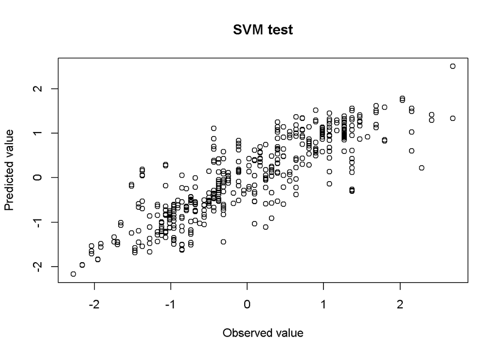

```r
#testing the model accuracy
svm.predicted.y.test.s.t.t <- predict(compounds.svr.s.t.t, newdata = multi.regression.x.test.s)
plot(preprocessed.y.test, svm.predicted.y.test.s.t.t,
     xlab="Observed value",
     ylab="Predicted value", main = "SVM test")
```

```r
svm.r2.test.s.t.t <- cor(preprocessed.y.test,svm.predicted.y.test.s.t.t)**2
svm.r2.test.s.t.t
```

```
## [1] 0.7417372
```

From here we study reverse analysis of the obtained model. But be careful! We should determine the AD (Applicability Domain) of the model before proceeding to the analysis. We use two types of the definition for checking AD, first is “Maharanobis Distance”. In this file we determine the oultlier of the newdata used for the reverse analysis as the data with Maharanobis Distance larger than the max value of the distance for the traindata.

```r
#--------------------------Bayesian optimization for hyperparameter tuning---------------------------

Mahalanobis <- function(dat,                 # 基準群のデータ行列
                        x)                      # 所属確率を計算するデータ行列
{
  dat <- subset(dat, complete.cases(dat))      # 欠損値を持つケースを除く
  n <- nrow(dat)                               # ケース数
  p <- ncol(dat)                               # 変数の個数
  ss <- var(dat)*(n-1)/n                       # 分散・共分散行列
  inv.ss <- solve(ss)                  # 分散共分散行列の逆行列
  m <- colMeans(dat)                   # 各変数の平均値
  dif <- t(t(x)-m)                     # 平均値からの偏差
  d2 <- apply(dif, 1,
              function(z) z %*% inv.ss %*% z) # マハラノビスの平方距離
  P <- pchisq(d2, p, lower.tail=FALSE) # 所属確率
  return(data.frame(d2=d2, P=P))
}

dat <- multi.regression.x.train.s[,] #固定する条件がある場合はここで除去
outlier <- max(Mahalanobis(dat, data.frame(dat))[,c(1)])
#maharanobis distによる外れ閾値
```

The second is “Data Density”, which is described as the reciprocal of the distance between the data and each cluster’s centers of gravity. Here the clustering is done by two steps; hierarchical clustering for determining the number of clusters and k-means clustering for calculating the Data Density.

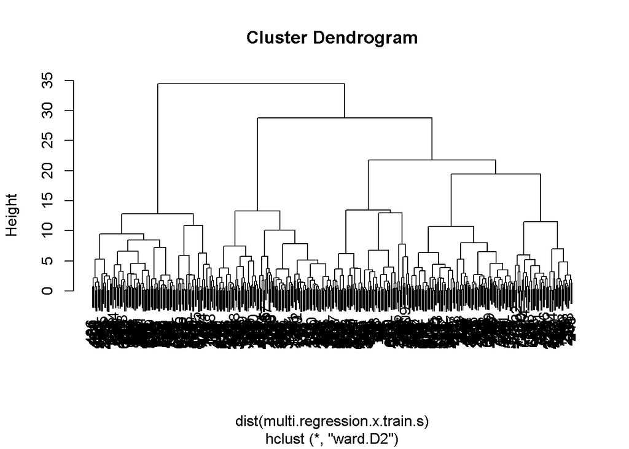

```r
#ここからクラスタリングによる外れ値検出
hist <- hclust(dist(multi.regression.x.train.s),method = "ward.D2")
plot(hist)
```

```r
# 階層型クラスタリングからクラスタ数を手動指定して分類する（コサイン類似度、ウォード法）。
clusnum <- 5
clusters <- cutree(hist, k = clusnum)

# クラスタiの中心点を算出
clust.centroid = function(i, dat, clusters) {
  ind = (clusters == i)
  colMeans(dat[ind,])
}

# 全クラスタに適用
centers <- sapply(unique(clusters), clust.centroid, multi.regression.x.train.s, clusters)

# k-meansの実行。sapply()の結果だと行と列が逆なので、転置して引数に与える
km <- kmeans(multi.regression.x.train.s, centers=t(centers))
hem <- sqrt(rowSums(multi.regression.x.train.s - fitted(km)) ^ 2)
outlierkm <- mean(hem) + 3*sd(hem)
#kmeansによる外れ値検出

nerv <- km$centers
distances <- matrix(data = 0, nrow = clusnum, ncol = 1)
minimumdistance <- function(v){
  for(pp in 1:clusnum){
  distances[c(pp), ] <- sqrt(rowSums(v - nerv[c(pp),]) ^ 2)
  }
  distances[c(which.min(distances)), ]}
```

Finally we proceed to the inverse analysis. We use rBayesianOptimization package here to maximize the response variable y. Please note that this package uses input data with the range of 0 to 1. Thus we scale the input values (a, b, c, d, e, f, g) for obtaining the range of -3 to 3. normally the package just searches the optimum condition, but we put some penarties for the data beyond AD(the predicted value becomes 0 if greater than 0).

```r
library(rBayesianOptimization)
Gauss_holdout <- function(a, b, c, d, e, f, g){
  daisen <- data.frame((a - 0.5)*6, (b - 0.5)*6, (c - 0.5)*6, (d - 0.5)*6, (e - 0.5)*6, (f - 0.5)*6, (g - 0.5)*6)
{  if(Mahalanobis(dat, data.frame(daisen[,]))[,c(1)] > outlier){ #固定する条件がある場合はここでdaisenから除去

    model <- compounds.svr.s.t.t
    Pred <- min(cbind(0, predict(model, data.frame(daisen)))) #最小化問題なら予測値に-1をかける
  list(Score=Pred, Pred=Pred)
}  else if(minimumdistance(daisen) > outlierkm){
      model <- compounds.svr.s.t.t
      Pred <- min(cbind(0, predict(model, data.frame(daisen))))
      list(Score=Pred, Pred=Pred)
#最小化問題なら予測値に-1をかける
}    else{
  model <- compounds.svr.s.t.t
  Pred <- predict(model, data.frame(daisen))　#最小化問題なら予測値に-1をかける

    list(Score=Pred, Pred=Pred)}}
    }

opt_svm <- BayesianOptimization(Gauss_holdout,bounds=list(a=c(0,1),b=c(0,1), c=c(0,1), d=c(0,1), e=c(0,1), f=c(0,1), g=c(0,1)), init_points=30, n_iter=1, acq='ei', kappa=2.576,eps=0.0, verbose=TRUE)
```

```
## elapsed = 0.05   Round = 1   a = 0.8328  b = 0.6737  c = 0.9054  d = 0.0181  e = 0.2095  f = 0.9073  g = 0.8047  Value = -0.6709
## elapsed = 0.00   Round = 2   a = 0.2587  b = 0.2351  c = 0.6463  d = 0.9415  e = 0.4138  f = 0.9146  g = 0.8903  Value = -0.3008
## elapsed = 0.02   Round = 3   a = 0.6996  b = 0.5207  c = 0.3511  d = 0.3879  e = 0.9537  f = 0.3095  g = 0.0073  Value = 0.2695
## elapsed = 0.01   Round = 4   a = 0.0879  b = 0.6186  c = 0.4561  d = 0.3601  e = 0.4847  f = 0.7708  g = 0.8140  Value = 1.4297
## elapsed = 0.00   Round = 5   a = 0.3086  b = 0.7287  c = 0.8203  d = 0.1872  e = 0.8344  f = 0.9738  g = 0.4858  Value = -0.3437
## elapsed = 0.00   Round = 6   a = 0.0827  b = 0.7268  c = 0.1326  d = 0.2819  e = 0.6760  f = 0.7893  g = 0.1704  Value = 0.0000
## elapsed = 0.02   Round = 7   a = 0.0486  b = 0.0223  c = 0.0220  d = 0.3095  e = 0.4334  f = 0.1600  g = 0.3859  Value = 0.0000
## elapsed = 0.00   Round = 8   a = 0.6862  b = 0.1837  c = 0.2122  d = 0.7538  e = 0.4171  f = 0.9303  g = 0.7346  Value = -0.2013
## elapsed = 0.00   Round = 9   a = 0.5375  b = 0.9826  c = 0.6672  d = 0.6785  e = 0.9431  f = 0.4879  g = 0.7790  Value = -0.1361
## elapsed = 0.00   Round = 10  a = 0.9681  b = 0.1777  c = 0.8143  d = 0.5816  e = 0.5663  f = 0.0681  g = 0.6730  Value = -0.2939
## elapsed = 0.00   Round = 11  a = 0.9643  b = 0.2808  c = 0.1165  d = 0.5818  e = 0.2653  f = 0.6037  g = 0.0881  Value = 0.0000
## elapsed = 0.00   Round = 12  a = 0.8539  b = 0.9002  c = 0.2236  d = 0.3397  e = 0.1262  f = 0.9943  g = 0.9702  Value = -0.1022
## elapsed = 0.02   Round = 13  a = 0.1853  b = 0.8517  c = 0.6121  d = 0.6798  e = 0.6985  f = 0.1578  g = 0.8714  Value = -0.4908
## elapsed = 0.00   Round = 14  a = 0.4944  b = 0.1799  c = 0.5409  d = 0.2338  e = 0.4278  f = 0.1020  g = 0.3476  Value = 0.0000
## elapsed = 0.00   Round = 15  a = 0.9002  b = 0.9738  c = 0.2435  d = 0.0432  e = 0.7165  f = 0.5224  g = 0.8911  Value = -0.0058
## elapsed = 0.00   Round = 16  a = 0.0553  b = 0.0265  c = 0.5439  d = 0.6867  e = 0.7156  f = 0.1586  g = 0.6270  Value = 0.0000
## elapsed = 0.01   Round = 17  a = 0.5413  b = 0.3513  c = 0.4325  d = 0.8307  e = 0.9176  f = 0.1683  g = 0.8546  Value = 0.4111
## elapsed = 0.00   Round = 18  a = 0.9815  b = 0.5484  c = 0.7795  d = 0.2277  e = 0.6647  f = 0.8929  g = 0.8185  Value = -0.8003
## elapsed = 0.00   Round = 19  a = 0.6234  b = 0.9442  c = 0.0302  d = 0.3525  e = 0.6352  f = 0.1025  g = 0.5961  Value = -0.0603
## elapsed = 0.00   Round = 20  a = 0.9209  b = 0.2984  c = 0.0144  d = 0.1582  e = 0.1402  f = 0.6857  g = 0.5307  Value = -0.2705
## elapsed = 0.01   Round = 21  a = 0.7969  b = 0.1277  c = 0.7283  d = 0.7840  e = 0.7315  f = 0.9793  g = 0.3483  Value = 0.0000
## elapsed = 0.00   Round = 22  a = 0.4114  b = 0.9398  c = 0.4965  d = 0.2811  e = 0.3953  f = 0.6391  g = 0.9321  Value = -0.0766
## elapsed = 0.00   Round = 23  a = 0.1674  b = 0.3770  c = 0.8840  d = 0.1740  e = 0.2870  f = 0.2539  g = 0.2914  Value = 0.0000
## elapsed = 0.02   Round = 24  a = 0.7190  b = 0.2241  c = 0.2457  d = 0.1825  e = 0.0424  f = 0.3441  g = 0.6504  Value = -0.3759
## elapsed = 0.00   Round = 25  a = 0.0390  b = 0.9677  c = 0.7379  d = 0.7758  e = 0.0479  f = 0.3665  g = 0.5392  Value = 0.0000
## elapsed = 0.01   Round = 26  a = 0.8045  b = 0.2481  c = 0.4493  d = 0.8381  e = 0.0262  f = 0.7250  g = 0.9846  Value = -0.2522
## elapsed = 0.00   Round = 27  a = 0.5036  b = 0.4141  c = 0.3877  d = 0.2924  e = 0.3983  f = 0.6690  g = 0.0075  Value = -0.1084
## elapsed = 0.02   Round = 28  a = 0.9854  b = 0.8993  c = 0.6114  d = 0.3171  e = 0.3462  f = 0.7757  g = 0.8844  Value = -0.2421
## elapsed = 0.02   Round = 29  a = 0.2380  b = 0.2756  c = 0.9351  d = 0.5404  e = 0.0209  f = 0.2005  g = 0.6294  Value = 0.0000
## elapsed = 0.00   Round = 30  a = 0.7005  b = 0.2212  c = 0.5433  d = 0.0706  e = 0.9011  f = 0.8769  g = 0.7414  Value = -0.1652
## elapsed = 0.00   Round = 31  a = 0.0000  b = 0.5970  c = 0.7114  d = 0.9737  e = 0.4250  f = 0.7321  g = 0.8214  Value = -0.2702
##
##  Best Parameters Found:
## Round = 4    a = 0.0879  b = 0.6186  c = 0.4561  d = 0.3601  e = 0.4847  f = 0.7708  g = 0.8140  Value = 1.4297
```